# yap1 hmVEC volcano plot and iVEC GO term barplot

Kobayashi et al. 2036

Tyrone Chen

August 05, 2026

# 1 README

Two unrelated one-off plots for the yap1 dataset, kept together since neither is large enough to warrant its own document:

1. hmVEC volcano plot (raw p-value, Hippo targets highlighted) - same convention as `meox1_volcano_plots.Rmd`.
2. iVEC GO term barplot from `enrichR` results, in an original and a “requested” (colour-by-score, p-value labelled) variant.

## 1.1 Outputs

Both under `../output/figure_extended/volcano/`:

- `yap1_dataset_Level_03_hmVEC_volcano_pvalue_RAW.pdf`
- `yap1_dataset_Level_03_ivec_barplot_GOterms.OLD.pdf` (original version)
- `yap1_dataset_Level_03_ivec_barplot_GOterms.pdf` (requested revision)

## 1.2 hmVEC volcano

Source: `yap1_edit_hmVEC_volcano.R`.

- v1 (2026-03-17): redo so y-axis is `-log10(raw p-value)`, x-axis is `log10(expression ratio)`, DEGs coloured.
- v2 (2026-03-18): DEG colouring switched from adjusted p-value to raw p-value < 0.05.

```r
library(tidyverse)
```

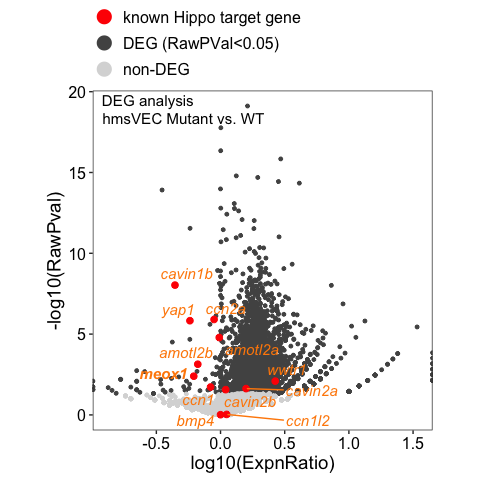

```r
library(ggplot2)
library(qs2)
library(Seurat)
outfile_dir <- "../output/figure_extended/volcano/"

all_degs <- read_csv(
    "../../Saki_data/analysis/D10025_yap1_dataset/DEGs/Level_03_DEG_mutVSwt_L3_celltype_fc0.00_minpct_0.01.csv",
    show_col_types = F
    )

hippo_targets <- c(
    "yap1",
    "wwtr1",
    "ccn2a",
    "ccn2b",
    "amotl2a",
    "amotl2b",
    "ccn1",
    "ccn1l2",
    "cavin1b",
    "cavin2a",
    "cavin2b",
    "bmp4",
    "meox1"
    )

# add expression ratios
all_degs$ExpnRatio <- all_degs$pct.1 / all_degs$pct.2
all_degs$LogExpnRatio <- log10(all_degs$ExpnRatio)

hmvec_data <- all_degs %>%
    filter(group == "hmVEC") %>%
    mutate(sig = ifelse(p_val < 0.05, "DEG (RawPVal<0.05)", "non-DEG"))

hippo_mark <- all_degs %>%
    filter(group == "hmVEC" & Gene %in% hippo_targets) %>%
    mutate(sig = ifelse(p_val < 0.05, "DEG (RawPVal<0.05)", "non-DEG"))

plot_discrete <- hmvec_data %>%
    ggplot(., aes(x = LogExpnRatio, y = -log10(p_val), colour = sig)) +
    geom_point(size=1) +
    geom_point(data = hippo_mark, colour="red", size=2, show.legend=FALSE) +
    ggrepel::geom_text_repel(
        data = hippo_mark,
        aes(label=Gene, fontface=ifelse(Gene=="meox1", "bold.italic", "italic")),
        size=4, colour="#ff8a04", show.legend=FALSE
    ) +
    scale_colour_manual(
        values = c(
            "known Hippo target gene" = "red",
            "DEG (RawPVal<0.05)" = "#525252",
            "non-DEG" = "#d9d9d9"
        ),
        breaks = c("known Hippo target gene", "DEG (RawPVal<0.05)", "non-DEG")
    ) +
    geom_point(data=data.frame(LogExpnRatio=NA_real_, p_val=NA_real_,
                               sig="known Hippo target gene"), aes(colour=sig)) +
    guides(colour = guide_legend(override.aes = list(shape=16, size=5), ncol=1)) +
    geom_text(
        data = data.frame(x=-Inf, y=Inf),
        aes(x=x, y=y, label="DEG analysis"),
        hjust=-0.1, vjust=1.4, size=4, colour="black",
        inherit.aes=FALSE
    ) +
    geom_text(
        data = data.frame(x=-Inf, y=Inf),
        aes(x=x, y=y, label="hmsVEC Mutant vs. WT"),
        hjust=-0.06, vjust=3.0, size=4, colour="black",
        inherit.aes=FALSE
    ) +
    labs(y="-log10(RawPval)", x="log10(ExpnRatio)") +
    theme_bw() +
    theme(
        axis.title = element_text(size=14),
        axis.text = element_text(size=12, colour="black"),
        legend.text = element_text(size=12),
        legend.title = element_blank(),
        legend.position = "top",
        legend.justification = "left",
        legend.background = element_blank(),
        legend.key = element_blank(),
        panel.grid = element_blank(),
        legend.spacing.y = unit(0.0, "cm"),
        legend.key.height = unit(0.3, "cm"),
        legend.margin = margin(0, 0, -2, 0),
        aspect.ratio = 1
    )

print(plot_discrete)
```

```r
ggsave(
    paste0(outfile_dir, "yap1_dataset_Level_03_hmVEC_volcano_pvalue_RAW.pdf"),
    plot_discrete,
    device="pdf",
    width=5,
    height=5
    )
```

## 1.3 iVEC GO term barplot

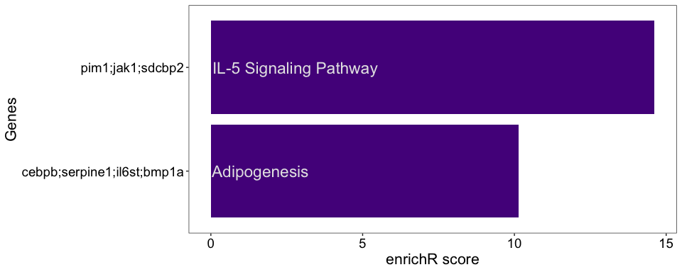

```r
go_terms <- qs_read("../../Saki_data/analysis/D10025_yap1_dataset/enrichR/D10025_yap1_dataset_markers_L3_celltype_top100_enrichR.qs2")

plot_sizing <- theme_bw() + theme(
    axis.title = element_text(size = 16),
    axis.text = element_text(size = 14, colour = "black"),
    plot.title = element_text(size = 18),
    legend.text = element_text(size = 14),
    legend.title = element_blank(),
    panel.grid = element_blank(),
    legend.position = "top",
    legend.justification = "left"
)

plot_original <- go_terms %>%
    mutate(., Term = gsub("_WP.*", "", Term)) %>%
    filter(., cluster == "iVEC" & Adjusted.P.value < 0.05) %>%
    ggplot(., aes(y = Genes, x = Combined.Score)) +
    geom_bar(stat="identity", fill = "purple4") +
    geom_text(aes(label = Term, x=0), colour = "grey90", size = 6, hjust=-0.01) +
    plot_sizing + xlab("enrichR score")

plot_requested <- go_terms %>%
    mutate(Term = gsub("_WP.*", "", Term)) %>%
    filter(cluster == "iVEC" & Adjusted.P.value < 0.05) %>%
    ggplot(., aes(y = reorder(Genes, -Adjusted.P.value), x = Adjusted.P.value, fill = Combined.Score)) +
    geom_bar(stat="identity") +
    geom_text(aes(label = Term, x=0), colour="green", size=6, hjust=-0.01) +
    geom_text(aes(label = formatC(Adjusted.P.value, digits=3, format="g"),
                  x=Adjusted.P.value,
                  colour="orange"),
                  size=4, hjust=1.1) +
    plot_sizing + theme(legend.title = element_text(size = 14)) +
    scale_fill_viridis_c(name="enrichR score") +
    scale_colour_identity() +
    xlab("AdjPval") + ylab("Genes")

print(plot_original)
```

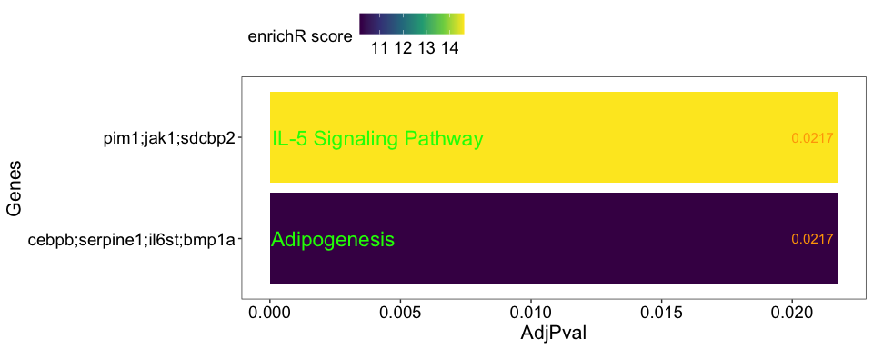

```r
print(plot_requested)
```

```r
outfile_dir_ivec <- "../output/figure_extended/volcano/"

ggsave(
    paste0(outfile_dir_ivec, "yap1_dataset_Level_03_ivec_barplot_GOterms.OLD.pdf"),
    plot_original,
    device="pdf",
    width=10,
    height=4
    )

ggsave(
    paste0(outfile_dir_ivec, "yap1_dataset_Level_03_ivec_barplot_GOterms.pdf"),
    plot_requested,
    device="pdf",
    width=10,
    height=4
    )
```

## 1.4 For developers

Sample run command:

```bash
Rscript -e "
rmarkdown::render(
  'yap1_volcano_plots.Rmd',
  output_file = './yap1_volcano_plots.html'
)
"
```